# Unsupervised Learning

```python
import pandas as pd
import numpy as np
import matplotlib.pyplot as plt
from sklearn.preprocessing import StandardScaler
```

## Principal Component Analysis

Here we use the USArrests dataset. This data set contains statistics, in arrests per 100,000 residents for assault, murder, and rape in each of the 50 US states in 1973. Also given is the percent of the population living in urban areas.

```python
Crime=pd.read_csv('USArrests.csv',index_col=0)
Crime.head()
```

|  | Murder | Assault | UrbanPop | Rape |
| --- | --- | --- | --- | --- |
| Alabama | 13.2 | 236 | 58 | 21.2 |
| Alaska | 10.0 | 263 | 48 | 44.5 |
| Arizona | 8.1 | 294 | 80 | 31.0 |
| Arkansas | 8.8 | 190 | 50 | 19.5 |
| California | 9.0 | 276 | 91 | 40.6 |

```python
Crime_stan= StandardScaler().fit_transform(Crime)
Crime_stan = pd.DataFrame(Crime_stan, index=Crime.index, columns = Crime.columns )
Crime_stan.head()
```

|  | Murder | Assault | UrbanPop | Rape |
| --- | --- | --- | --- | --- |
| Alabama | 1.255179 | 0.790787 | -0.526195 | -0.003451 |
| Alaska | 0.513019 | 1.118060 | -1.224067 | 2.509424 |
| Arizona | 0.072361 | 1.493817 | 1.009122 | 1.053466 |
| Arkansas | 0.234708 | 0.233212 | -1.084492 | -0.186794 |
| California | 0.281093 | 1.275635 | 1.776781 | 2.088814 |

PCA in sklearn follows similar syntax as other sklearn functions. Here we use only the first two principal component.

```python
from sklearn.decomposition import PCA
pca = PCA(n_components=2)
pca.fit(Crime_stan)
```

```
PCA(copy=True, iterated_power='auto', n_components=2, random_state=None,
    svd_solver='auto', tol=0.0, whiten=False)
```

```python
pca.components_
```

```
array([[ 0.53589947,  0.58318363,  0.27819087,  0.54343209],
       [ 0.41818087,  0.1879856 , -0.87280619, -0.16731864]])
```

This corresponds to $\phi$ in the lecture notes

```python
sum(pca.components_[0,:]**2)
```

```
1.0000000000000002
```

```python
sum(pca.components_[0,:]*pca.components_[1,:])
```

```
-1.3877787807814457e-16
```

Clearly, different principal components are orthogonal to each other. The norm of each principal component is one.

```python
pcscore = pca.transform(Crime_stan)
pcscore
```

```
array([[ 0.98556588,  1.13339238],
       [ 1.95013775,  1.07321326],
       [ 1.76316354, -0.74595678],
       [-0.14142029,  1.11979678],
       [ 2.52398013, -1.54293399],
       [ 1.51456286, -0.98755509],
       [-1.35864746, -1.08892789],
       [ 0.04770931, -0.32535892],
       [ 3.01304227,  0.03922851],
       [ 1.63928304,  1.2789424 ],
       [-0.91265715, -1.57046001],
       [-1.63979985,  0.21097292],
       [ 1.37891072, -0.68184119],
       [-0.50546136, -0.15156254],
       [-2.25364607, -0.10405407],
       [-0.79688112, -0.2701647 ],
       [-0.75085907,  0.95844029],
       [ 1.56481798,  0.87105466],
       [-2.39682949,  0.37639158],
       [ 1.76336939,  0.42765519],
       [-0.48616629, -1.4744965 ],
       [ 2.10844115, -0.15539682],
       [-1.69268181, -0.63226125],
       [ 0.99649446,  2.39379599],
       [ 0.69678733, -0.26335479],
       [-1.18545191,  0.53687437],
       [-1.26563654, -0.19395373],
       [ 2.87439454, -0.7756002 ],
       [-2.38391541, -0.01808229],
       [ 0.18156611, -1.44950571],
       [ 1.98002375,  0.14284878],
       [ 1.68257738, -0.82318414],
       [ 1.12337861,  2.22800338],
       [-2.99222562,  0.59911882],
       [-0.22596542, -0.74223824],
       [-0.31178286, -0.28785421],
       [ 0.05912208, -0.54141145],
       [-0.88841582, -0.57110035],
       [-0.86377206, -1.49197842],
       [ 1.3207238 ,  1.93340466],
       [-1.98777484,  0.82334324],
       [ 0.99974168,  0.8602513 ],
       [ 1.35513821, -0.41248082],
       [-0.55056526, -1.47150461],
       [-2.80141174,  1.40228806],
       [-0.09633491,  0.19973529],
       [-0.21690338, -0.97012418],
       [-2.10858541,  1.4248467 ],
       [-2.07971417, -0.61126862],
       [-0.62942666,  0.32101297]])
```

```python
sum(pcscore[:,1]*pcscore[:,0])
```

```
-8.493206138382448e-15
```

Different principal component score vectors are also orthogonal to each other. The reason of which is not explained in the lecture.

PVE can be calculated using pcscore. It is also in explained_variance*ratio* feature.

```python
sum(pcscore**2)/200
```

```
array([0.62006039, 0.24744129])
```

```python
pca.explained_variance_ratio_
```

```
array([0.62006039, 0.24744129])
```

```python
pca_inverse= pd.DataFrame(pca.inverse_transform(pcscore), index=Crime.index, columns = Crime.columns )
pca_inverse
```

|  | Murder | Assault | UrbanPop | Rape |
| --- | --- | --- | --- | --- |
| Alabama | 1.002127 | 0.787827 | -0.715056 | 0.345950 |
| Alaska | 1.493875 | 1.339037 | -0.394197 | 0.880199 |
| Arizona | 0.632934 | 0.888019 | 1.141572 | 1.082972 |
| Arkansas | 0.392491 | 0.128032 | -1.016707 | -0.264215 |
| California | 0.707374 | 1.181895 | 2.048831 | 1.629773 |
| Colorado | 0.398677 | 0.697622 | 1.283282 | 0.988298 |
| Connecticut | -1.183467 | -0.997044 | 0.572460 | -0.556135 |
| Delaware | -0.110491 | -0.033340 | 0.297248 | 0.080365 |
| Florida | 1.631092 | 1.764531 | 0.803962 | 1.630820 |
| Georgia | 1.413320 | 1.196426 | -0.660235 | 0.676848 |
| Hawaii | -1.145829 | -0.827471 | 1.116814 | -0.233200 |
| Idaho | -0.790543 | -0.916645 | -0.640316 | -0.926420 |
| Illinois | 0.453825 | 0.675982 | 0.978716 | 0.863429 |
| Indiana | -0.334257 | -0.323268 | -0.008330 | -0.249325 |
| Iowa | -1.251241 | -1.333850 | -0.536125 | -1.207293 |
| Kansas | -0.540026 | -0.515515 | 0.014116 | -0.387847 |
| Kentucky | -0.001584 | -0.257716 | -1.045415 | -0.568406 |
| Louisiana | 1.202844 | 1.076322 | -0.324944 | 0.704629 |
| Maine | -1.127060 | -1.327036 | -0.995293 | -1.365491 |
| Maryland | 1.123826 | 1.108761 | 0.117293 | 0.886717 |
| Massachusetts | -0.877142 | -0.560708 | 1.151703 | -0.017488 |
| Michigan | 1.064929 | 1.200396 | 0.722180 | 1.171795 |
| Minnesota | -1.171507 | -1.106000 | 0.080953 | -0.814069 |
| Mississippi | 1.535061 | 1.031138 | -1.812104 | 0.141000 |
| Missouri | 0.263278 | 0.356848 | 0.423698 | 0.422721 |
| Montana | -0.410772 | -0.590411 | -0.798369 | -0.734042 |
| Nebraska | -0.759362 | -0.774559 | -0.182805 | -0.655335 |
| Nevada | 1.216045 | 1.530498 | 1.476579 | 1.691811 |
| New Hampshire | -1.285101 | -1.393660 | -0.647401 | -1.292471 |
| New Jersey | -0.508854 | -0.166600 | 1.315648 | 0.341198 |
| New Mexico | 1.120830 | 1.181571 | 0.426145 | 1.052107 |
| New York | 0.557452 | 0.826505 | 1.186558 | 1.052101 |
| North Carolina | 1.533726 | 1.073969 | -1.632101 | 0.237694 |
| North Dakota | -1.352992 | -1.632391 | -1.355324 | -1.726315 |
| Ohio | -0.431485 | -0.271309 | 0.584969 | 0.001393 |
| Oklahoma | -0.287459 | -0.235939 | 0.164506 | -0.121269 |
| Oregon | -0.194724 | -0.067299 | 0.488994 | 0.122717 |
| Pennsylvania | -0.714925 | -0.625468 | 0.251311 | -0.387238 |
| Rhode Island | -1.086812 | -0.784208 | 1.061915 | -0.219766 |
| South Carolina | 1.516288 | 1.133677 | -1.320074 | 0.394229 |
| South Dakota | -0.720941 | -1.004461 | -1.271600 | -1.217981 |
| Tennessee | 0.895502 | 0.744748 | -0.472714 | 0.399356 |
| Texas | 0.553726 | 0.712754 | 0.737003 | 0.805441 |
| Utah | -0.910403 | -0.597702 | 1.131176 | -0.052985 |
| Vermont | -0.914865 | -1.370128 | -2.003253 | -1.757006 |
| Virginia | 0.031900 | -0.018634 | -0.201130 | -0.085771 |
| Washington | -0.521926 | -0.308864 | 0.786390 | 0.044448 |
| West Virginia | -0.534146 | -0.961842 | -1.830204 | -1.384276 |
| Wisconsin | -1.370139 | -1.327765 | -0.045038 | -1.027907 |
| Wyoming | -0.203068 | -0.306726 | -0.455283 | -0.395762 |

```python
sum(((pca_inverse-Crime_stan)**2).sum())
```

```
26.49966341553326
```

```python
sum(((pca_inverse)**2).sum())
```

```
173.50033658446688
```

```python
sum(((Crime_stan)**2).sum())
```

```
200.0
```

```python
sum(pca.explained_variance_ratio_)
```

```
0.8675016829223337
```

```python
1-sum(((pca_inverse-Crime_stan)**2).sum())/sum(((Crime_stan)**2).sum())
```

```
0.8675016829223337
```

Next, we validate our shortcut methods to calculate the PCs.

```python
Crime_stan.cov()
```

|  | Murder | Assault | UrbanPop | Rape |
| --- | --- | --- | --- | --- |
| Murder | 1.020408 | 0.818238 | 0.070992 | 0.575080 |
| Assault | 0.818238 | 1.020408 | 0.264155 | 0.678818 |
| UrbanPop | 0.070992 | 0.264155 | 1.020408 | 0.419736 |
| Rape | 0.575080 | 0.678818 | 0.419736 | 1.020408 |

```python
np.linalg.eig(Crime_stan.cov())
```

```
(array([2.53085875, 1.00996444, 0.17696948, 0.36383998]),
 array([[ 0.53589947,  0.41818087,  0.6492278 , -0.34123273],
        [ 0.58318363,  0.1879856 , -0.74340748, -0.26814843],
        [ 0.27819087, -0.87280619,  0.13387773, -0.37801579],
        [ 0.54343209, -0.16731864,  0.08902432,  0.81777791]]))
```

```python
pca = PCA()
pca.fit(Crime_stan)
print(pca.components_)
print(pca.explained_variance_)
```

```
[[ 0.53589947  0.58318363  0.27819087  0.54343209]
 [ 0.41818087  0.1879856  -0.87280619 -0.16731864]
 [-0.34123273 -0.26814843 -0.37801579  0.81777791]
 [ 0.6492278  -0.74340748  0.13387773  0.08902432]]
[2.53085875 1.00996444 0.36383998 0.17696948]
```

### Visualization

#### The biplot

```python
z1=pcscore[:,0]
z2=pcscore[:,1]
phi1=pca.components_[0]
phi2=pca.components_[1]
```

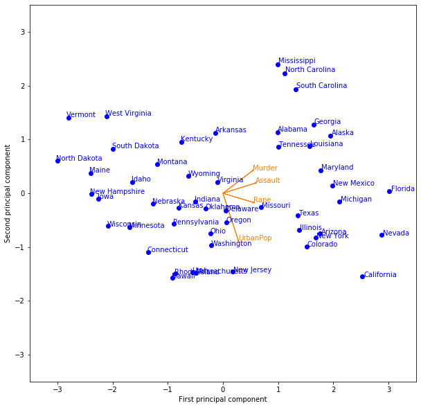

```python
plt.figure(figsize=(10,10))
for i in range(len(z1)):
    plt.plot(z1[i], z2[i], 'bo') ## 'b' denote for blue, 'o' denote for circle
    plt.text(z1[i]*1.01, z2[i]*1.01, Crime.index[i], color='b') ## Place the text

for j in range(len(phi1)):
    plt.arrow(0, 0, phi1[j], phi2[j],
              color='tab:orange', width=0.0005, head_width=0.025)
    plt.text(phi1[j]*1.01, phi2[j]*1.01,
             Crime.columns[j], color='tab:orange')
plt.axis([-3.5,3.5, -3.5, 3.5])
plt.xlabel('First principal component')
plt.ylabel('Second principal component')
plt.show()
```

#### The scree plot

```python
pve = pca.explained_variance_ratio_
pve
```

```
array([0.62006039, 0.24744129, 0.0891408 , 0.04335752])
```

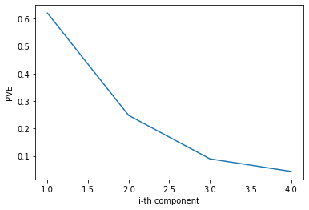

```python
plt.plot(np.array(range(len(pve))) + 1,pve)
plt.xlabel('i-th component')
plt.ylabel('PVE')
plt.show()
```

```python
cpve = np.cumsum(pve)
cpve
```

```
array([0.62006039, 0.86750168, 0.95664248, 1.        ])
```

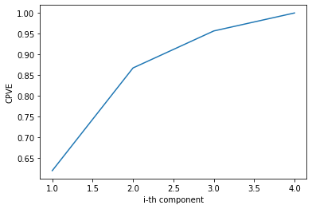

```python
plt.plot(np.array(range(len(cpve))) + 1,cpve)
plt.xlabel('i-th component')
plt.ylabel('CPVE')
plt.show()
```

## K-means Clustering

```python
from sklearn.cluster import KMeans
```

We first use clustering on the two-dimension representation of the USArrest data.

```python
pcscore
```

```
array([[ 0.98556588,  1.13339238],
       [ 1.95013775,  1.07321326],
       [ 1.76316354, -0.74595678],
       [-0.14142029,  1.11979678],
       [ 2.52398013, -1.54293399],
       [ 1.51456286, -0.98755509],
       [-1.35864746, -1.08892789],
       [ 0.04770931, -0.32535892],
       [ 3.01304227,  0.03922851],
       [ 1.63928304,  1.2789424 ],
       [-0.91265715, -1.57046001],
       [-1.63979985,  0.21097292],
       [ 1.37891072, -0.68184119],
       [-0.50546136, -0.15156254],
       [-2.25364607, -0.10405407],
       [-0.79688112, -0.2701647 ],
       [-0.75085907,  0.95844029],
       [ 1.56481798,  0.87105466],
       [-2.39682949,  0.37639158],
       [ 1.76336939,  0.42765519],
       [-0.48616629, -1.4744965 ],
       [ 2.10844115, -0.15539682],
       [-1.69268181, -0.63226125],
       [ 0.99649446,  2.39379599],
       [ 0.69678733, -0.26335479],
       [-1.18545191,  0.53687437],
       [-1.26563654, -0.19395373],
       [ 2.87439454, -0.7756002 ],
       [-2.38391541, -0.01808229],
       [ 0.18156611, -1.44950571],
       [ 1.98002375,  0.14284878],
       [ 1.68257738, -0.82318414],
       [ 1.12337861,  2.22800338],
       [-2.99222562,  0.59911882],
       [-0.22596542, -0.74223824],
       [-0.31178286, -0.28785421],
       [ 0.05912208, -0.54141145],
       [-0.88841582, -0.57110035],
       [-0.86377206, -1.49197842],
       [ 1.3207238 ,  1.93340466],
       [-1.98777484,  0.82334324],
       [ 0.99974168,  0.8602513 ],
       [ 1.35513821, -0.41248082],
       [-0.55056526, -1.47150461],
       [-2.80141174,  1.40228806],
       [-0.09633491,  0.19973529],
       [-0.21690338, -0.97012418],
       [-2.10858541,  1.4248467 ],
       [-2.07971417, -0.61126862],
       [-0.62942666,  0.32101297]])
```

```python
kmeans = KMeans(n_clusters=3, random_state=20)
kmeans.fit(pcscore)
```

```
KMeans(algorithm='auto', copy_x=True, init='k-means++', max_iter=300,
       n_clusters=3, n_init=10, n_jobs=None, precompute_distances='auto',
       random_state=20, tol=0.0001, verbose=0)
```

```python
kmeans.labels_
```

```
array([1, 1, 1, 0, 1, 1, 0, 0, 1, 1, 0, 2, 1, 0, 2, 0, 2, 1, 2, 1, 0, 1,
       0, 1, 1, 2, 0, 1, 2, 0, 1, 1, 1, 2, 0, 0, 0, 0, 0, 1, 2, 1, 1, 0,
       2, 0, 0, 2, 2, 0], dtype=int32)
```

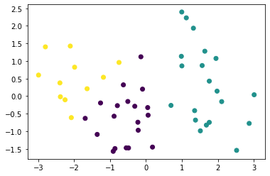

```python
z1=pcscore[:,0]
z2=pcscore[:,1]
plt.scatter(z1, z2, c=kmeans.labels_)
plt.show()
```

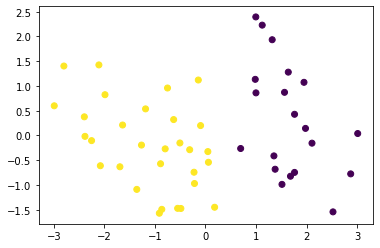

```python
kmeans = KMeans(n_clusters=2, random_state=20)
kmeans.fit(pcscore)
z1=pcscore[:,0]
z2=pcscore[:,1]
plt.scatter(z1, z2, c=kmeans.labels_)
plt.show()
```

What if we use the whole dataset, instead of the dimension reduced score?

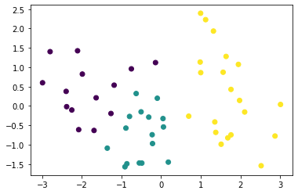

```python
kmeans = KMeans(n_clusters=3, random_state=20)
kmeans.fit(Crime_stan)
z1=pcscore[:,0]
z2=pcscore[:,1]
plt.scatter(z1, z2, c=kmeans.labels_)
plt.show()
```

Almost the same as before! Meaning that the first two PC already recover most of the data pattern.

## Hierarchical Clustering

```python
from scipy.cluster import hierarchy
```

The linkage function is to compute the linkage matrix, which store all the information about the dendrogram. Then we can use dendrogram function to plot the dendrogram.

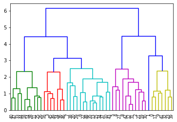

```python
Z=hierarchy.linkage(Crime_stan,method='complete')
hierarchy.dendrogram(Z,color_threshold=3)
plt.show()
```

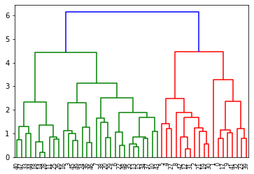

```python
hierarchy.dendrogram(Z,color_threshold=5)
plt.show()
```

We can also find labels using fcluster functions. You can either determine the cut point or no. of clusters.

```python
hierarchy.fcluster(Z,5.1,criterion='distance')
```

```
array([2, 2, 2, 1, 2, 2, 1, 1, 2, 2, 1, 1, 2, 1, 1, 1, 1, 2, 1, 2, 1, 2,
       1, 2, 1, 1, 1, 2, 1, 1, 2, 2, 2, 1, 1, 1, 1, 1, 1, 2, 1, 2, 2, 1,
       1, 1, 1, 1, 1, 1], dtype=int32)
```

```python
hierarchy.fcluster(Z,3.1,criterion='distance')
```

```
array([5, 6, 4, 2, 4, 4, 3, 3, 4, 5, 3, 1, 4, 3, 1, 3, 2, 5, 1, 4, 3, 4,
       3, 5, 2, 1, 1, 4, 1, 3, 4, 4, 5, 1, 3, 3, 2, 3, 3, 5, 1, 5, 4, 3,
       1, 2, 2, 1, 3, 2], dtype=int32)
```

```python
hierarchy.fcluster(Z,3,criterion='maxclust')
```

```
array([3, 3, 2, 1, 2, 2, 1, 1, 2, 3, 1, 1, 2, 1, 1, 1, 1, 3, 1, 2, 1, 2,
       1, 3, 1, 1, 1, 2, 1, 1, 2, 2, 3, 1, 1, 1, 1, 1, 1, 3, 1, 3, 2, 1,
       1, 1, 1, 1, 1, 1], dtype=int32)
```

Again, we can visualize the result.

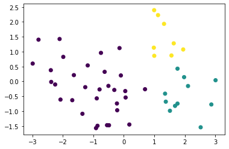

```python
clusters=hierarchy.fcluster(Z,3,criterion='maxclust')
z1=pcscore[:,0]
z2=pcscore[:,1]
plt.scatter(z1, z2, c=clusters)
plt.show()
```

It is quite different from k-means.

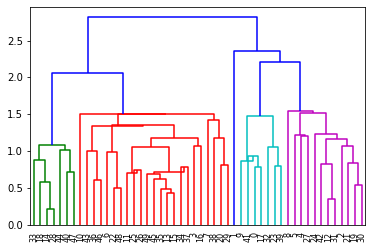

```python
Z=hierarchy.linkage(Crime_stan,method='centroid')
hierarchy.dendrogram(Z)
plt.show()
```

We can see inversions when using 'centroid' methods.